# R 機率預測評估方法

## KS曲線

接下來有個跟ROC曲線類似的圖，其基於Kolmogorov-Smirnov兩樣本檢驗的邏輯設計。  
我們已經熟悉了ROC曲線怎麼畫了，接下來了解KS曲線與KS值就很容易。  
ROC曲線中，橫軸是假正率FPR，縱軸是真正率TPR，線上每一點是不同門檻值對應到的（FPR,TPR）組合。而KS曲線中，我們把假正率也拉到縱軸，獨立變成另一條曲線，縱軸就是兩個值的累積分布函數，而原本的橫軸則為門檻值（預測為正的機率值）。整張圖詮釋預測機率從小到大，正率與負率的變動，計算兩條曲線的差值取最大的作為KS值。

KS值是模型將正樣本和負樣本區分開來的最大分類能力。KS值越大，表示模型能夠將正、負分類分開的程度越大，模型的預測準確性越好。KS值的範圍是[0，1]。KS值大於0.2時，即可認為模型預測準確性達到可用要求。一般模型KS值介於0.2到0.6之間，很難超過0.6。

由於KS值能找出模型中差異最大的一個門檻值，因此也適合用來找門檻值cut off。但是KS值只能反映出哪個門檻值是區分最大的，較不能總體反映出總體模型的分類效果，這點AUC值更能勝任。不過單單比較兩個模型的KS值，也仍然能當作分類能力的參考。如果模型中採用的Feature不佳，沒辦法有效分類樣本，那麼AUC值就會很低，不管門檻值怎麼調都不會好。

承接ROC圖，這裡繼續使用ROCR包繪圖，這裡先以門檻值為底。

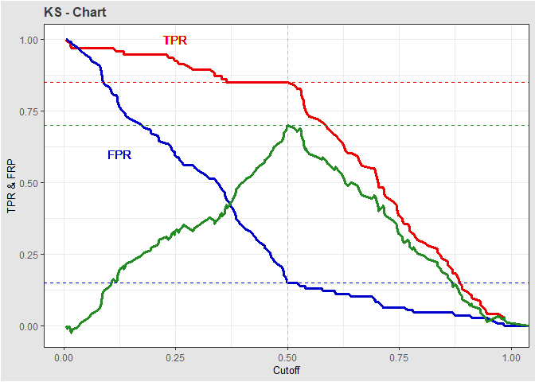

```r
perf <- ROCR::performance(pred,"tpr","fpr")
FPR=attr(perf,'x.values')[[1]]
TPR=attr(perf,'y.values')[[1]]
Cutoff=attr(perf,'alpha.values')[[1]]
ks_df <- data.frame(FPR,TPR,Cutoff,KS=TPR-FPR)

ks_max <- max(ks_df$KS)
plotKS <- ggplot(ks_df)+
  geom_line(aes(Cutoff,TPR),colour="red2",size=1.2)+
  geom_line(aes(Cutoff,FPR),colour="blue3",size=1.2)+
  geom_line(aes(Cutoff,TPR-FPR),colour="forestgreen",size=1.2)+
  geom_vline(xintercept=ks_df[ks_df$KS==ks_max,"Cutoff"],linetype=2,colour="gray",size=0.6)+
  geom_hline(yintercept=ks_df[ks_df$KS==ks_max,"TPR"],linetype=2,colour="red2",size=0.6)+
  geom_hline(yintercept=ks_df[ks_df$KS==ks_max,"FPR"],linetype=2,colour="blue3",size=0.6)+
  geom_hline(yintercept=ks_df[ks_df$KS==ks_max,"KS"],linetype=2,colour="forestgreen",size=0.6)+
  geom_text(aes(x = 0.25, y = 1.0, label = "TPR"),colour="red2") +
  geom_text(aes(x = 0.125, y = 0.60, label = "FPR"), colour = "blue3") +
  xlab("Cutoff")+
  ylab("TPR & FRP")+
  ggtitle(label="KS - Chart")+
  theme_bw()+
  theme(plot.title=element_text(colour="gray24",size=12,face="bold"),
        plot.background = element_rect(fill = "gray90"),
        axis.title=element_text(size=10),
        axis.text=element_text(colour="gray35"),
        legend.position = "right")
plotKS
```

但實際的KS圖，會改用預測機率的百分比作為橫軸，陽性或陰性的累積佔比為Y軸，而為什麼不用上面的畫法呢？  
因為門檻值對應到樣本被預測出來的機率，如果機率多集中在某些值附近，就無法畫出如上圖從門檻值0開始到1都還算滑順的圖。  
因此實際作法如下：  
1. 模型產出預測為陽性的機率值，我們先將資料已此機率值由大到小排序。  
2. 依排序後的機率值由大到小算出不同的百分位數。 預測機率的百分位數，理解為Depth = proportion allocated to class positive，預測成正例的比例 Depth=25，表示所有樣本中有百分之25被歸納為陽性。

接下來也示範一下，不使用`ROCR`計算TPR、FPR，而是自己手刻的寫法。

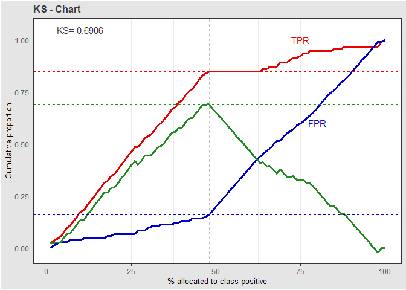

```
##
## $ks_max
## [1] 0.6905839
```

```r
ks.plot = function(prediction,label,n=100){
df <- data.frame(prediction,label) %>% arrange(desc(prediction))
total_positive <- sum(df$label)
total_negative <- nrow(df)-total_positive
# n代表將機率區間0-1要等比例分成幾份
# 如果有超過100個樣本，則切100份，否則，分割數等同於樣本個數
if(n > nrow(df)){n <- nrow(df)}
df$rownum <- 1:nrow(df)
qus <- quantile(1:nrow(df),probs=seq(0,1,1/n)) #把原本的總比數切成n份
success_prop <- failure_prop <- NULL
out <- mapply(function(i){
  sub_df <- df[df$rownum < ifelse(i==n,qus[i+1]+0.001,qus[i+1]),] #隨著機率遞減
  success_prop <<-c(success_prop,sum(sub_df$label==1)) #實際為1的累積個數
  failure_prop <<-c(failure_prop,sum(sub_df$label==0)) #實際為0的累積個數
  },1:n)
success_prop <- success_prop/total_positive
failure_prop <- failure_prop/total_negative
ks_df <- data.frame(rownum=1:n,success_prop,failure_prop,KS=success_prop-failure_prop)
ks_max <- max(ks_df$KS)
# 繪製曲線
plotKS <- ggplot()+
  geom_line(aes(ks_df$rownum,ks_df$success_prop),colour="red2",size=1.2)+
  geom_line(aes(ks_df$rownum,ks_df$failure_prop),colour="blue3",size=1.2)+
  geom_line(aes(ks_df$rownum,ks_df$KS),colour="forestgreen",size=1.2)+
  geom_vline(xintercept=ks_df[ks_df$KS==ks_max,"rownum"],linetype=2,colour="gray",size=0.6)+
  geom_hline(yintercept=ks_df[ks_df$KS==ks_max,"success_prop"],linetype=2,colour="red2",size=0.6)+
  geom_hline(yintercept=ks_df[ks_df$KS==ks_max,"failure_prop"],linetype=2,colour="blue3",size=0.6)+
  geom_hline(yintercept=ks_df[ks_df$KS==ks_max,"KS"],linetype=2,colour="forestgreen",size=0.6)+
  annotate("text", x = 10, y = 1.05, label=paste("KS=", round(ks_max, 4)), size=4,alpha=0.8)+
  geom_text(aes(x = 75, y = 1.0, label = "TPR"),colour="red2") +
  geom_text(aes(x = 80, y = 0.6, label = "FPR"), colour = "blue3") +
  xlab("% allocated to class positive")+
  ylab("Cumulative proportion")+
  ggtitle(label="KS - Chart")+
  theme_bw()+
  theme(plot.title=element_text(colour="gray24",size=12,face="bold"),
        plot.background = element_rect(fill = "gray90"),
        axis.title=element_text(size=10),
        axis.text=element_text(colour="gray35"))
  return(list(plotKS=plotKS,ks_max=ks_max))
}

ks.plot(ROCR.simple$predictions,ROCR.simple$labels,100)
```

## Gain 累積增益圖 / Lift 累積提升圖

跟上圖同樣原理，我們把縱軸的指標換一下，換成Gain值和Lift值，可以得到累積增益圖和累積提升圖。
橫軸一樣是總樣本數中預測成陽性的比例，就是上面講的Depth，也被表示成Rate of Positive Predictions
$$RPP(Rate\ of\ positive\ predictions) =\frac{TP+FP}{P+N}$$
當門檻值不同時，RPP會變動，其值範圍為[0,1]。

累積增益圖其實就是KS圖只留下TPR那條線，Gain為所有正類中，成功被分類為正的比例，增益圖反映門檻值設定不同時，對應到的不同召回率。
$$Gain=\frac{TP}{TP+FN}$$

另外，提升值(Lift Value)則進一步考慮了在某個RPP下的TPR(Recall) $TPR=\frac{TP}{TP+FN}$的這個相對性概念，用TPR/RPP計算。
$$Lift=\frac{\frac{TP}{TP+FN}}{\frac{TP+FP}{P+N}}$$

這裡就偷懶，直接用`ROCR`的功能來產！

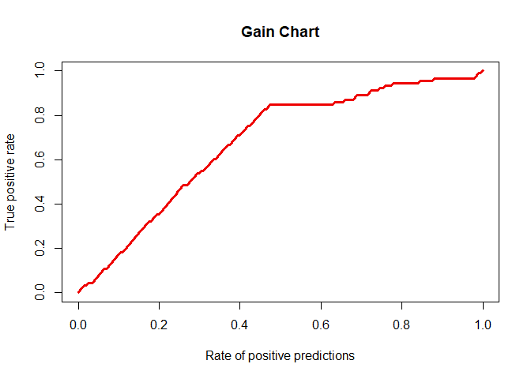

```r
pred <- ROCR::prediction(ROCR.simple$predictions, ROCR.simple$labels)
gain <- ROCR::performance(pred, "tpr", "rpp")
plot(gain, main = "Gain Chart",col = "red2", lwd = 3)
```

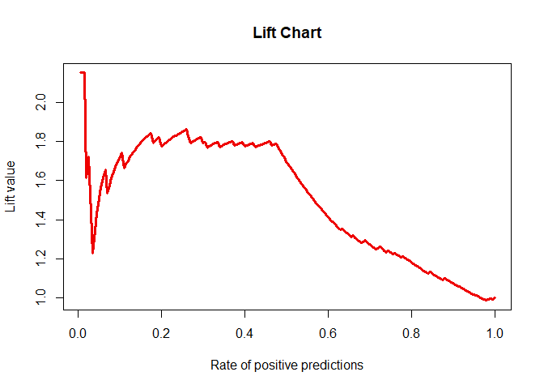

```r
lift <- ROCR::performance(pred,"lift","rpp")
plot(lift, main = "Lift Chart",col = "red2", lwd = 3)
```

## Response 累積回應圖

所謂回應，可以用個簡單的例子說明。  
如果針對100個客戶進行行銷，其中5位參與，回應率就是5%。  
那我們實際為正的個數除以模型分類出來為正的個數比值，就是回應Response值。 累積回應圖就是基於各分位數Depth對應區間中的回應率繪製的。 結果會跟Lift圖很類似，只是縱軸的尺度不一樣。

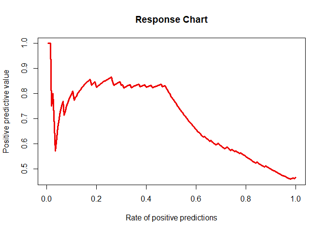

```r
pred <- ROCR::prediction(ROCR.simple$predictions, ROCR.simple$labels)
response <- ROCR::performance(pred,"ppv","rpp")
plot(response, main = "Response Chart",col = "red2", lwd = 3)
```

參考資料：  
[程式前沿](https://codertw.com/%E7%A8%8B%E5%BC%8F%E8%AA%9E%E8%A8%80/674564/#outline__1_6)  
[ITread](https://www.itread01.com/content/1544662627.html)  
[Tommy大的Medium](https://medium.com/@chih.sheng.huang821/%E6%A9%9F%E5%99%A8%E5%AD%B8%E7%BF%92-%E7%B5%B1%E8%A8%88%E6%96%B9%E6%B3%95-%E6%A8%A1%E5%9E%8B%E8%A9%95%E4%BC%B0-%E9%A9%97%E8%AD%89%E6%8C%87%E6%A8%99-b03825ff0814)  
[Rstudio for ROC curves](https://rviews.rstudio.com/2019/03/01/some-r-packages-for-roc-curves/)  
[Binary Classifier evaluation](https://rpubs.com/riazakhan94/ksroclift)

如果內容有任何問題或錯誤，歡迎來信跟我聯絡唷！ ivan0628@gmail.com